# PSY 8712 Week 8 Project

Ben Elliott

2026-03-19

# Reproducible Image and Online Resources

An image of this project as of *2026-03-19* can be accessed by clicking this link.  
An interactive web app is available by [clicking this link instead](https://ellio747.shinyapps.io/shiny_week8/).

# Script Settings and Resources

```r
setwd(dirname(rstudioapi::getActiveDocumentContext()$path)) # set wd
library(tidyverse) # data science tools
library(kableExtra) # data rendering to notebook
```

# Data Import and Cleaning

I imported and cleaned in a similar fashion that we had in previous weeks. New this week, I reverse coded Q5 based on a judgment that the q items are in Likert-style values of 1 - 5 which allowed me to mutate the variable by subtracting the item value from 6. I also created two new variables using `mutate` called `x_mean` and `y_mean` which were the `rowMeans()` of Q1-Q6 and Q8-Q10 respectively to conduct future analysis and visualizations. I muted the message about the column types to enhance the readability of the notebook.

```r
week8_tbl <- read_csv("../data/week3.csv", show_col_types = FALSE) %>%
  mutate(
    timeStart = ymd_hms(timeStart),
    condition = factor(condition, levels = c("A", "B", "C"), labels = c("Block A", "Block B", "Control")),
    gender = factor(gender, levels = c("M", "F"), labels = c("Male", "Female")),
    q5 = 6 - q5,
    x_mean = rowMeans(across(q1:q6), na.rm = TRUE),
    y_mean = rowMeans(across(q8:q10), na.rm = TRUE)
  )
```

# Visualization

For visualizations, I displayed the data contained within the variables Q1-Q6, piping into `kable()` for an aesthetically pleasing visual display that provides all 49 observations. Second using the mean values generated for the two sub-scales (Q1-Q6 & Q8-Q10) I plotted using `ggplot2`, adding a linear model (OLS) smoothing function, the standard error band, and the color of the regression line using the appropriate parameters. Finally, I included appropriate axis labels. Code chunk options were modified to only ouptut the kable-created table and ggplot-created scatterplot.

| q1 | q2 | q3 | q4 | q5 | q6 |
| --- | --- | --- | --- | --- | --- |
| 5 | 4 | 4 | 1 | 2 | 1 |
| 2 | 4 | 3 | 1 | 3 | 1 |
| 5 | 5 | 2 | 1 | 5 | 1 |
| 4 | 3 | 4 | 2 | 4 | 1 |
| 3 | 1 | 3 | 5 | 2 | 1 |
| 4 | 3 | 2 | 3 | 3 | 1 |
| 2 | 4 | 1 | 3 | 1 | 1 |
| 4 | 2 | 5 | 1 | 1 | 1 |
| 2 | 5 | 3 | 4 | 2 | 1 |
| 3 | 4 | 2 | 4 | 5 | 1 |
| 5 | 2 | 3 | 1 | 5 | 1 |
| 3 | 1 | 3 | 5 | 4 | 1 |
| 5 | 5 | 2 | 3 | 4 | 1 |
| 1 | 3 | 5 | 4 | 2 | 1 |
| 4 | 1 | 5 | 1 | 1 | 1 |
| 1 | 3 | 2 | 4 | 5 | 3 |
| 2 | 5 | 4 | 3 | 4 | 1 |
| 4 | 4 | 1 | 3 | 5 | 1 |
| 2 | 3 | 1 | 1 | 4 | 1 |
| 3 | 1 | 2 | 2 | 1 | 1 |
| 3 | 4 | 3 | 3 | 5 | 1 |
| 3 | 1 | 1 | 2 | 3 | 1 |
| 5 | 4 | 4 | 2 | 5 | 1 |
| 5 | 2 | 1 | 2 | 4 | 4 |
| 3 | 3 | 1 | 4 | 5 | 1 |
| 5 | 1 | 3 | 4 | 5 | 1 |
| 2 | 4 | 5 | 4 | 2 | 1 |
| 2 | 4 | 5 | 5 | 3 | 1 |
| 5 | 5 | 3 | 2 | 4 | 1 |
| 1 | 4 | 2 | 4 | 2 | 1 |
| 4 | 1 | 4 | 5 | 1 | 1 |
| 3 | 4 | 3 | 2 | 1 | 1 |
| 3 | 5 | 5 | 5 | 5 | 5 |
| 3 | 1 | 5 | 5 | 2 | 1 |
| 3 | 1 | 2 | 4 | 5 | 1 |
| 3 | 3 | 1 | 1 | 1 | 1 |
| 4 | 2 | 2 | 5 | 1 | 1 |
| 1 | 3 | 3 | 5 | 4 | 1 |
| 5 | 4 | 3 | 3 | 1 | 1 |
| 5 | 1 | 5 | 2 | 2 | 1 |
| 3 | 3 | 4 | 1 | 2 | 1 |
| 5 | 4 | 1 | 1 | 2 | 1 |
| 4 | 5 | 3 | 2 | 2 | 1 |
| 4 | 1 | 3 | 1 | 2 | 1 |
| 5 | 3 | 3 | 5 | 5 | 1 |
| 1 | 4 | 2 | 2 | 1 | 1 |
| 2 | 1 | 1 | 3 | 1 | 1 |
| 4 | 1 | 5 | 2 | 4 | 1 |
| 4 | 2 | 3 | 1 | 3 | 1 |

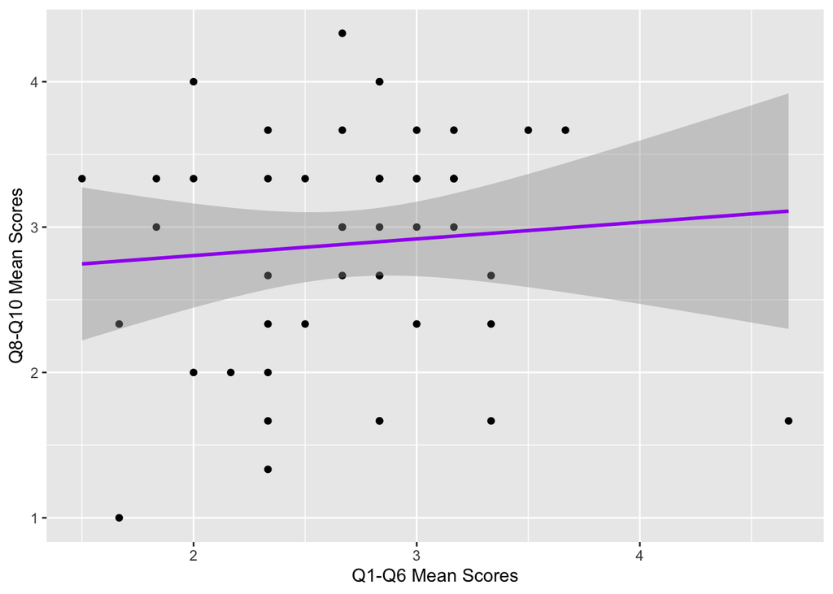

# Analysis

For the analysis section, I created a new variable `cor_test` in my environment which stored the results of the correlation test using the `stats` package’s `cor.test()` function. I saved this new variable so that I could call the results below the chunk to dynamically explain the resultant correlation and associated p-value from the enviornment.

```r
cor_test <- cor.test(week8_tbl$x_mean, week8_tbl$y_mean)
cor_test
```

```
##
##  Pearson's product-moment correlation
##
## data:  week8_tbl$x_mean and week8_tbl$y_mean
## t = 0.58309, df = 47, p-value = 0.5626
## alternative hypothesis: true correlation is not equal to 0
## 95 percent confidence interval:
##  -0.2012466  0.3574248
## sample estimates:
##        cor
## 0.08474575
```

I observed a correlation of .08 between the Q1-Q6 and Q8-Q10 subscales. Yet the p-value of the correlation test is .56 which is non-significant, meaning that we fail to reject the null hypothesis that the mean correlation is zero.

# Data Export

For the data export section, I looked ahead at what variables would be required for the shiny app and only included those that were required to enable the app to function. Therefore, I only retained the timeStart, gender, and composite scale means. I saved an RDS file according to the instructions and placed into the subdirectory where the shiny app would be generated. I opted to minimize the data in the skinny dataset to maintain data integrity while safeguarding the item-level responses and treatment groups.

```r
(week8_tbl_skinny <- week8_tbl %>%
  select(timeStart, gender, x_mean, y_mean)) %>%
  saveRDS(file = "../shiny/shiny_week8/week8_tbl_skinny.rds")
```